# PSC mice P76_3 part1

- Show All Code
- Hide All Code
- View Source

Rnaseq dataset

# 1 Introduction

This report presents a preliminary transcriptomic analysis of liver samples from a PSC mouse model (experiment P76_3), asking how diet and sex jointly shape hepatic gene expression.

RNA-seq data was processed using custom bioinformatic pipeline available at https://github.com/xpolak37/RNAseq_workflow.

Data from 44 animals (SD: 10F/11M; GFD: 11F/12M) were modeled in DESeq2 using the design Date + Diet + Sex + Diet:Sex, with SD and female as reference levels; the Diet×Sex interaction is the primary term of interest, since it tests whether diet acts differently in the two sexes rather than assuming a single “overall” diet effect.

After filtering to genes with ≥5 counts in at least one full group, 16602 genes were retained.

The workflow combines global structure (PCA, sample-distance heatmap, PERMANOVA), targeted differential expression, curated gene panels (masculinization, lipogenesis, liver-damage, bile-acid), integration with serum bile-acid phenotypes and clinical parameters, and pathway enrichment (Hallmark, KEGG, Reactome).

One caveat runs through the whole analysis: collection order/date carries circadian (time-of-day) information and is partly entangled with the biological signal.

**Open code**

```r
source("custom_functions_rnaseq.R")
```

# 2 Import

Two inputs are loaded:

**Open code**

```r
# load gene level data
gene_df <- fread("../../Data/tpm_data.tsv") %>% as.data.frame()

# load metadata
sample_metadata <- read.xlsx("../../Data/metadata_P076v3.xlsx",detectDates = TRUE) %>%
  dplyr::filter(!is.na(SampleIAB)) %>%
  dplyr::mutate(Group=paste(Diet,Sex,sep = "_")) %>%
  dplyr::mutate(SampleID=SampleIAB)
```

**Open code**

```r
group_colours <- c("GFD_F"="#e59866",
                   "GFD_M"= "#7fb3d5",
                   "SD_F"="#b03a2e",
                  "SD_M"="#1c4c78")
```

# 3 Number of identified genes

For each sample, the chunk below counts how many genes have expression above zero (TPM > 0). The non-sample columns of the expression table (the gene identifier columns) are excluded first. A sample with clearly fewer detected genes than the rest would suggest low library complexity or a technical problem.

**Open code**

```r
sample_metadata$number_of_genes <- apply(gene_df[,-c(45,46)],2,function(x) sum(as.numeric(x)>0,na.rm = TRUE))
```

The bar plot shows the number of detected genes per sample, coloured by group. Samples should look broadly similar; no group should be systematically lower, since that would be a technical difference that could masquerade as biology.

**Open code**

```r
p <- ggplot(sample_metadata) +
  geom_col(aes(x=SampleID,y=number_of_genes,fill=Group)) +
  scale_fill_manual(values = group_colours) +
  ylab("Number of identified genes") + xlab("Sample")

p <- ggtheme(p) +
  theme(axis.text.x = element_text(angle=45,hjust = 1,size = 5))
```

**Open code**

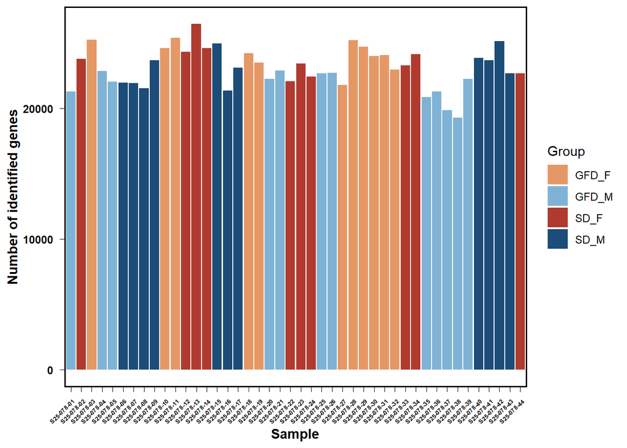

```r
p
```

# 4 Sequencing depth

Sequencing depth is the total number of reads obtained for each sample (taken from the metadata). Uneven depth is expected to some degree and is corrected by normalization, but very shallow samples carry less information and noisier estimates for lowly expressed genes. As above, depth should not differ systematically between groups.

**Open code**

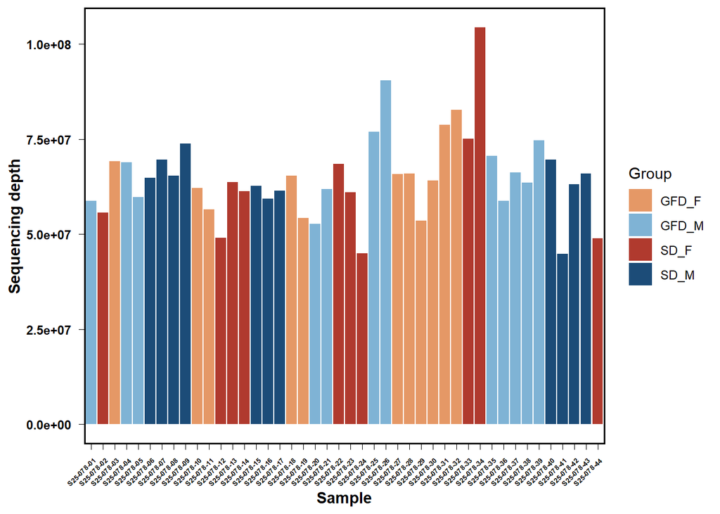

```r
p <- ggplot(sample_metadata) +
  geom_col(aes(x=SampleID,y=Seq_depth,fill=Group)) +
  scale_fill_manual(values = group_colours) +
  ylab("Sequencing depth") + xlab("Sample")

p <- ggtheme(p) +
  theme(axis.text.x = element_text(angle=45,hjust = 1,size = 5))

p
```

# 5 Exploratory data analysis

## 5.1 Table 1

**Open code**

```r
df <- tableone::CreateTableOne(vars = c(colnames(sample_metadata)[c(-1,-2,-11,-13)]),
                                data = sample_metadata,
                                factorVars = "Group",
                                test = FALSE)
```

**Open code**

```r
df_overall <- print(df, showAllLevels = TRUE, quote = FALSE, noSpaces = TRUE, printToggle = FALSE)

df_overall %>% kable(
    caption = "Table 1",
    digits  = 8,
    booktabs = TRUE,
    align = "ccc"
  ) %>%
  kable_styling(
    latex_options = c("hold_position"),
    bootstrap_options = c("striped", "hover", "condensed")
  )
```

Table 1

|  | level | Overall |
| --- | --- | --- |
| n |  | 44 |
| Sex (%) | F | 21 (47.7) |
|  | M | 23 (52.3) |
| Diet (%) | GFD | 23 (52.3) |
|  | SD | 21 (47.7) |
| age_days (mean (SD)) |  | 26.14 (0.63) |
| mistnost (%) | D.0.09 | 44 (100.0) |
| stojan (mean (SD)) |  | 1.00 (0.00) |
| mother (mean (SD)) |  | 601.48 (41.42) |
| father (mean (SD)) |  | 606.77 (34.56) |
| pokus (%) | 76_3 | 44 (100.0) |
| sex (%) | F | 21 (47.7) |
|  | M | 23 (52.3) |
| diet (%) | GFD | 23 (52.3) |
|  | SD | 21 (47.7) |
| Date (%) | 26-11 | 23 (52.3) |
|  | 27-11 | 21 (47.7) |
| Order (mean (SD)) |  | 12.34 (6.92) |
| Seq_depth (mean (SD)) |  | 64881930.77 (11130631.25) |
| Identified_genes (mean (SD)) |  | 23093.34 (1519.38) |
| Group (%) | GFD_F | 11 (25.0) |
|  | GFD_M | 12 (27.3) |
|  | SD_F | 10 (22.7) |
|  | SD_M | 11 (25.0) |
| number_of_genes (mean (SD)) |  | 23093.34 (1519.38) |

## 5.2 PCA

**Open code**

```r
### sample to sample PCA
pca_data <- as.data.frame(t(gene_df[,-c(45,46)]))
pca_data_filtered <- pca_data[, apply(pca_data, 2, var) != 0]

p12 <- pca_plot(pca_data_filtered,sample_metadata,colors = group_colours,
                axis = c("PC1","PC2"))
```

**Open code**

```r
p23 <- pca_plot(pca_data_filtered,sample_metadata,colors = group_colours,
                axis = c("PC2","PC3"))
```

**Open code**

```r
p13 <- pca_plot(pca_data_filtered,sample_metadata,colors = group_colours,
                axis = c("PC1","PC3"))
```

**Open code**

```r
ggplotly(p12, tooltip = "text")
```

[interactive chart not shown]

**Open code**

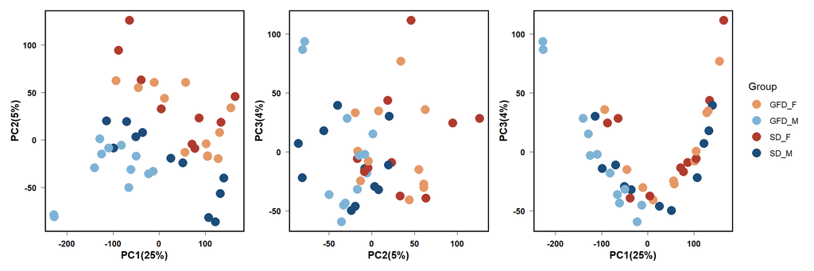

```r
p <- wrap_plots(p12,p23,p13,guides = "collect")

p
```

## 5.3 Heatmap

The heatmap shows expression of all genes (rows) across all samples (columns). Expression is log2(TPM + 1)-transformed, so that a few very highly expressed genes do not dominate the colour scale; adding 1 avoids taking the log of zero. Genes are kept in their original order (not clustered), while samples are hierarchically clustered, so samples with similar profiles end up next to each other.

**Open code**

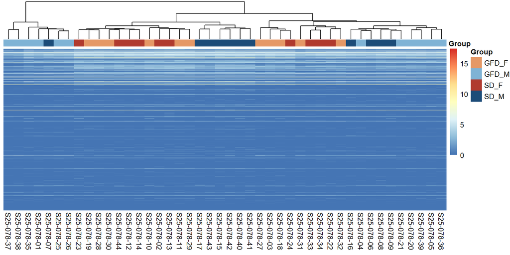

```r
library(pheatmap)
p_df <- gene_df[,-c(45)] %>%
  `rownames<-`(NULL) %>%
  column_to_rownames("gene_id")

p_df <- log2(p_df+1)

ann_df <- sample_metadata %>% dplyr::select(SampleID,Group) %>%
  column_to_rownames("SampleID")

ann_colors <- list(
  "Group"=unique(group_colours)
)
names(ann_colors[["Group"]]) <- unique(names(group_colours))

p <- pheatmap(p_df,cluster_rows = FALSE,show_rownames = FALSE,
              annotation_col = ann_df,annotation_colors = ann_colors)
```